# Lab3. Correlation and Simple Linear Regression

Robert van Timmeren (S4535553)

Generation date: May 11, 2021 - 22:56:25

# 1 Load Data

Create the 2 vectors for our numerical variables: translation quality and overlap.

```r
tquality = c(0.3735,
             0.3322,
             0.2196,
             0.2559,
             0.2485,
             0.3422,
             0.1611,
             0.3248,
             0.2978,
             0.3558,
             0.3255,
             0.2537)
overlap = c(0.3680,
            0.3926,
            0.3702,
            0.3708,
            0.4037,
            0.3771,
            0.2163,
            0.3346,
            0.3432,
            0.4331,
            0.4481,
            0.3683)
```

# 2 Scatter Plot

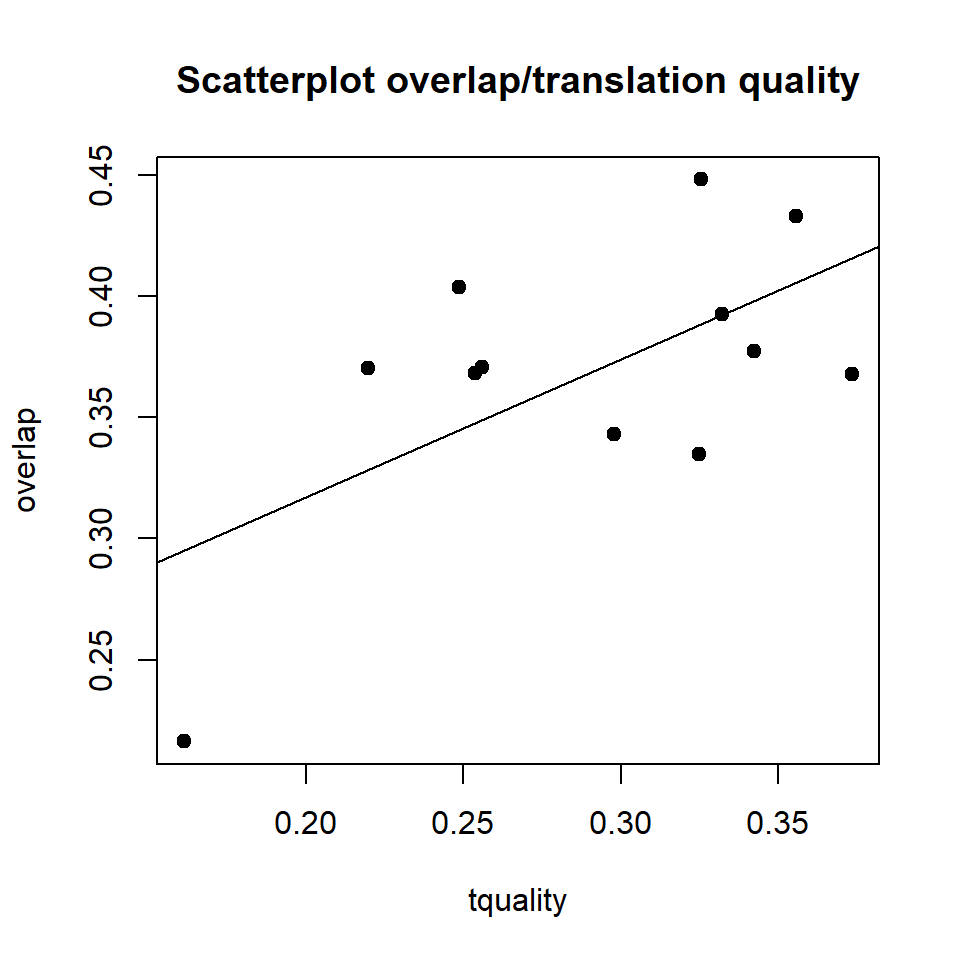

```r
plot(overlap ~ tquality, col = 'black', pch = 19, main = "Scatterplot overlap/translation quality")
abline(lm(overlap ~ tquality))
```

# 3 Scatter Plot Interpretation

It seems that as overlap value goes up, so does the translation quality. So there does seem to be a positive correlation between the two. However you can tell there is an outlier, this does seem to impact the correlation line.

# 4 Pearson

```r
cor.test(overlap, tquality, method = 'pearson')
```

```
##
##  Pearson's product-moment correlation
##
## data:  overlap and tquality
## t = 2.4857, df = 10, p-value = 0.03223
## alternative hypothesis: true correlation is not equal to 0
## 95 percent confidence interval:
##  0.06831204 0.87984054
## sample estimates:
##       cor
## 0.6179859
```

The Pearson correlation between overlap and translation quality is positive with r = 0.6179859, df = 10 and p-value (two-tailed) <= 0.05. As such, there is a positive correlation between the two variables and the result is significant.